# Exploring the BRFSS data

## Setup

### Load packages

```r
library(ggplot2)
library(dplyr)
library(corrplot)
library(maps)
load("brfss2013.RData")
```

## Part 1: Data

1. Observations in the sample of 50 states were collected using Random Digit Dialing (RDD) techniques to make calls to landlines and cell phones. One individual is surveyed in each family using a standardized questionaire that ranges from health status to HIV/AIDS knowledge and prevention. Observations were collected from the non-institutionalized adult population aged 18 years and older.
2. As the participants were interviewed at random via telephone, this implies that the findings of the study is generalized only to US adults who have access to a telephone. This excludes the homeless population.
3. Due to privacy concerns, participants may also be dishonest about existing health conditions.
4. Causality cannot be confirmed through this study as it is observational and not experimental, hence only associations can be concluded.

## Part 2: Research questions

**Research quesion 1:** Are participants from certain states healthier than others? Is there a difference in health across different states? 3 variables: genhlth, poorhlth and X-state can be used to answer this question.

**Research quesion 2:** Is better health associated with better accessibility to healthcare? Accessbility to healthcare is mainly determined by cost. Using variables htlthpln1, checkup1, income2 and medcost it is possible to determine if cost is associated with frequency of checkups and better health status.

**Research quesion 3:** Is stroke truly associated with obesity, smoking and alcohol consumption? Or is stroke a random occurence? Using variables cvdstrk3, toldhi2, alcday5, smokday2 and X_bmi, we can conclude of stroke is associated with these factors in the adult US population.

## Part 3: Exploratory data analysis

**Research quesion 1:** Are participants from certain states healthier than others?

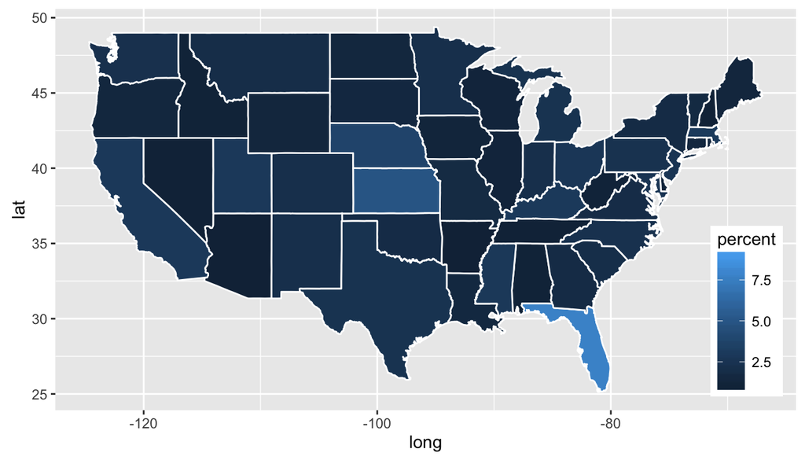

```r
states <- map_data("state")

health <- brfss2013 %>%
  filter(!is.na(genhlth)) %>%
  select(genhlth, X_state, poorhlth)

poor_hlth <- health %>%
  group_by(genhlth, X_state) %>%
  summarise(mean(poorhlth), n=n()) %>%
  mutate(percent = (n/sum(n))*100)

health_map <- poor_hlth %>%
  mutate(region = tolower(X_state))

map_state <- merge(states, health_map, by ="region")

ggplot() + geom_polygon(data = map_state, aes(long, lat, group = group, fill = percent), color = "white") + theme(legend.position = c(1,0), legend.justification = c(1,0))
```

**Research quesion 2:** Is better health associated with better accessibility to healthcare? Is medical cost associated with frequency of medical checkups and hence accesibility of healthcare? Using Florida as a case study, we can investigate if medical cost is associated with poor health.

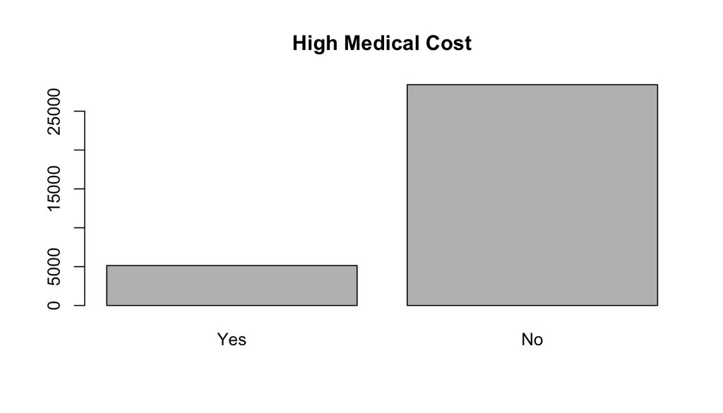

```r
plot(brfss2013 %>%
       filter(!is.na(medcost), X_state == "Florida") %>%
       select(medcost), main= "High Medical Cost")
```

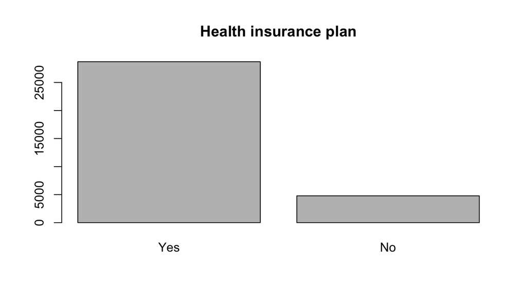

```r
plot(brfss2013 %>%
       filter(X_state=="Florida") %>%
       select(hlthpln1), main="Health insurance plan")
```

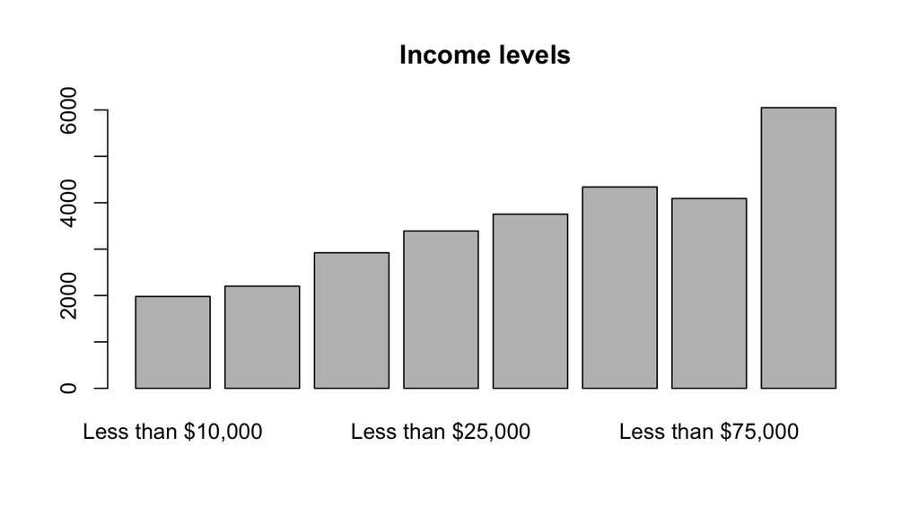

```r
plot(brfss2013 %>%
       filter(X_state=="Florida") %>%
       select(income2), main="Income levels")
```

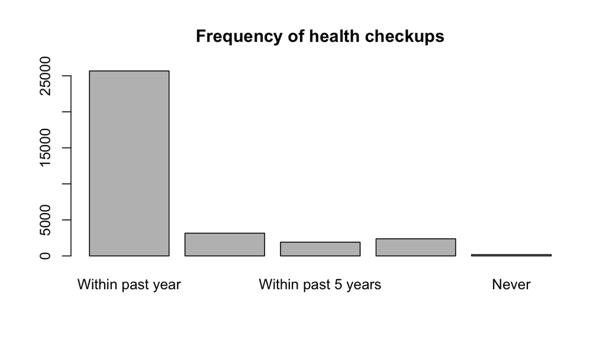

```r
plot(brfss2013 %>%
       filter(X_state=="Florida") %>%
       select(checkup1), main="Frequency of health checkups")
```

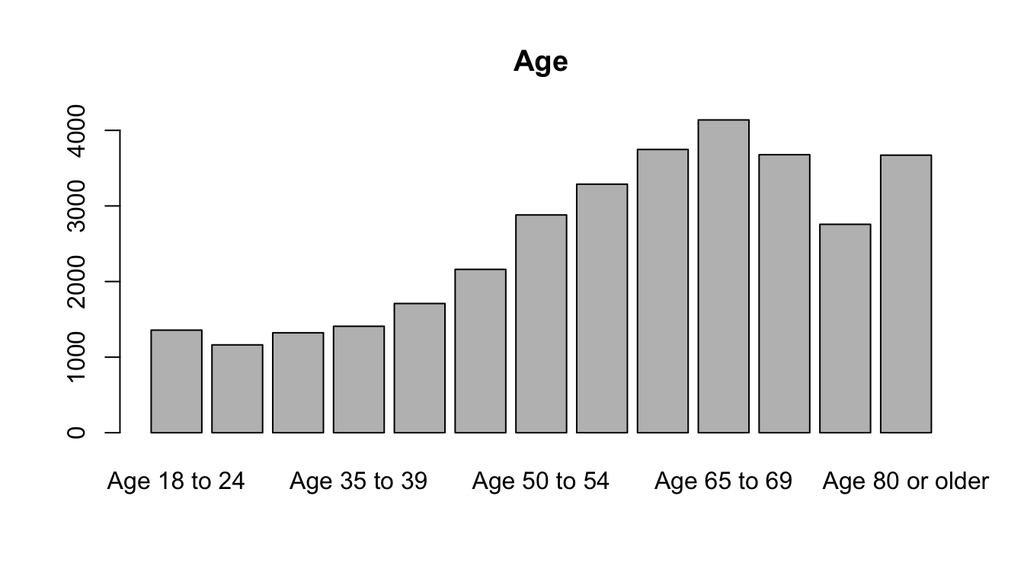

```r
plot(brfss2013 %>%
       filter(X_state=="Florida") %>%
       select(X_ageg5yr), main="Age")
```

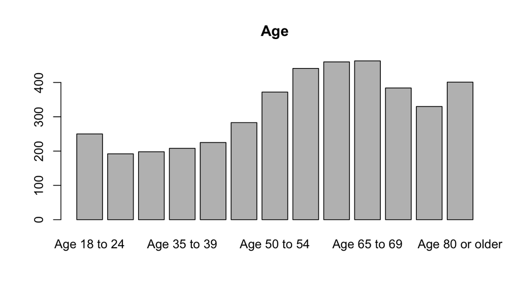

```r
plot(brfss2013 %>%
       filter(X_state=="Arizona") %>%
       select(X_ageg5yr), main="Age")
```

The higher percentage of poor health in Florida is cannot be attributed to inaccessbility to healthcare as the data shows that most participants do go for medical checkups frequently and that healthcare is affordable for them. Age may account for the higher percentage of poor health as the participants in Arizona have relatively fewer elderly than Florida.

**Research quesion 3:** Is stroke truly associated with obesity, smoking and alcohol consumption?

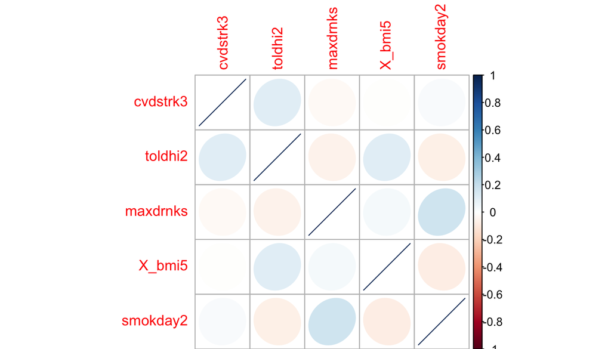

```r
stroke <- brfss2013 %>%
  filter(!is.na(cvdstrk3), !is.na(X_bmi5), !is.na(maxdrnks), !is.na(toldhi2), !is.na(smokday2),X_state=="Florida") %>%
  select(cvdstrk3, toldhi2, maxdrnks, X_bmi5, smokday2)

stroke$cvdstrk3 <- ifelse(stroke$cvdstrk3=="Yes",1,0)
stroke$toldhi2 <- ifelse(stroke$toldhi2 == "Yes",1,0)
stroke$smokday2 <- ifelse(stroke$smokday2 == "Every day", 2,0)

correlate <-cor(stroke)
corrplot(correlate, method="ellipse")
```

**End**